# Question

The blue curve represents $y=f(x)$. The red curve represents $y=g(x)$.

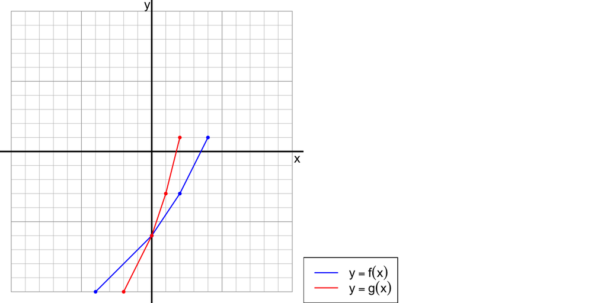

What equation expresses the function transformation?

## Answerlist

- $g(x)= f{\left(\frac{x}{2}\right)}$
- $g(x)= \frac{f(x)}{3}$
- $g(x)= f{\left(\frac{x}{3}\right)}$
- $g(x)=2\cdot f(x)$
- $g(x)= \frac{f(x)}{2}$
- $g(x)= f{\left(3\cdot x\right)}$
- $g(x)=3\cdot f(x)$
- $g(x)= f{\left(2\cdot x\right)}$

# Solution

We see the points are transformed horizontally, so we are expecting the operation **inside the argument**. We also remember that horizontal transformations are “backwards”.

In this case, we see from blue to red, the points have shrunk towards the vertical axis by a factor of 2. In other words, the coordinate transformation is:

$$(a,b)\to
\left(\frac{a}{2}~,~b\right)$$

Unfortunately, when we express the transformation as an equation in function notation, we see the inverse operation. So, instead of division, we see multiplication. So, the correct answer is:

$$g(x)= f{\left(2\cdot
x\right)}$$

For example, in the graph we see $g(2) = f(4) = 1$. We see this because the red curve has a point at $(2,1)$ and the blue curve has a corresponding point at $(4,1)$. It might help to visually check all the following:

$$g(-2) = f(-4)$$
$$g(0) = f(0)$$
$$g(1) = f(2)$$
$$g(2) = f(4)$$

# Meta-information

extype: schoice exsolution: 00000001 exname: hor_squeeze